# Bloque 3

Septiembre, 2017

## Temas

- Buenas prácticas
- Tipos de formatos
- Fuentes de datos
- Variables necesarias
- Ejemplos

## Buenas prácticas

- Todo nuestro esfuerzo es para obtener datos, **hay que cuidarlos**
- Nombres de columna
  - Sin espacios (usar *snake_case, CamelCase* o *dot.case*)
  - Sin caracteres especiales
  - Sin unidades
- Metadatos
- Almacenamiento online (*e.g.* mySQL, KoBo Toolbox, Open Data Kit)
- Sistemas de control de versión (*e.g.* GitHub, SVN, Mercurial)
- Aprovechar todas las opciones "OpenScience" Lowndes et al. (2017)
- Crear capacidad de manejo de datos más allá de Excel / Access

## Tipos de formato

- Casi cualquier base de datos puede tenerse en dos formatos
- Formato ancho
  - Una variable ocupa varias columnas (la base tiende a ser ancha)
  - Cada una de estas columnas tiene valores de otra variable
- Formato largo
  - Una variable por columna, una fila por registro

## Tipos de formato

Producción pesquera de 2 recursos en 3 años

| Recurso | 2015 | 2016 | 2017 |
| --- | --- | --- | --- |
| Mero | 10 | 15 | 22 |
| Barracuda | 20 | 28 | 18 |

- Se lee "fácil"
- Difícil hacer gráficas, prueba de hipótesis, análisis
- No sabemos lo que se reporta las celdas
- Bueno para reportar datos en forma tabular (*e.g.* tabla en un reporte)

## Formato de datos

**Ejemplo largo**

Producción pesquera de 2 recursos en 3 años

| Recurso | Año | Arribos |
| --- | --- | --- |
| Mero | 2015 | 10 |
| Barracuda | 2015 | 20 |
| Mero | 2016 | 15 |
| Barracuda | 2016 | 28 |
| Mero | 2017 | 22 |
| Barracuda | 2017 | 18 |

- No es tan fácil de leer para nosotros
- Ideal para hacer análisis (`lm(Arribos ~ Año + Recurso)`)
- Formato requerido por muchos softwares de análisis y visualización (*e.g.* Tableau, miniTab, Statistica, SPSS)
- Permite orden jerárquico

## Formato de datos

**Ejemplo largo**

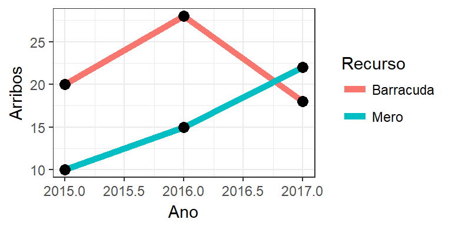

```r
library(ggplot2)

ggplot(df2, aes(x = Ano, y = Arribos, color = Recurso)) +
  geom_line(size = 2) +
  geom_point(size = 3, color = "black") +
  theme_bw()
```

## Fuentes de datos

**Una comunidad costera**

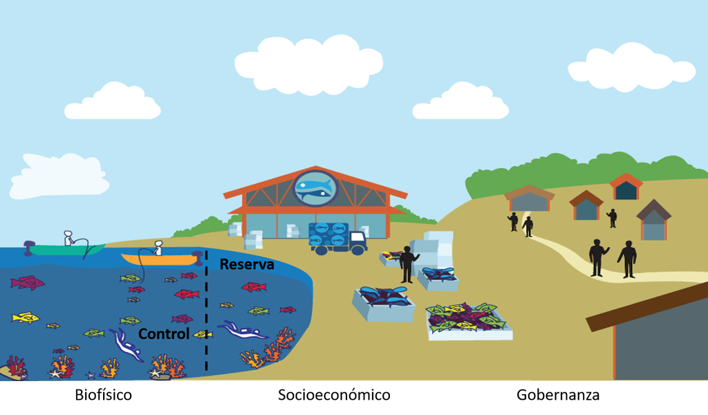

## Variables mínimas necesarias: Biológicos

- Año
- Comunidad
- Sitio
- Zona
- **RC**
- Transecto
- Profunidad
- Visibilidad
- Temperatura
- GeneroEspecie
- Talla
- Abudnancia
- Historia de vida (*a*, *b*, *NT*, *Lm*)
- Ejemplo

## Ejemplo biológico

| Ano | Sitio | Zona | RC | Transecto | Prof | Vis | Temp | GeneroEspecie | Talla | Abundancia |
| --- | --- | --- | --- | --- | --- | --- | --- | --- | --- | --- |
| 2007 | Babencho | Control | La Plana / Las Cuevas - La Dulce / Babencho | 10 | 7.8 | 8 | 18 | Chromis punctipinnis | 10 | 14 |
| 2007 | Babencho | Control | La Plana / Las Cuevas - La Dulce / Babencho | 10 | 7.8 | 8 | 18 | Halichoeres semicinctus | 10 | 5 |
| 2007 | Babencho | Control | La Plana / Las Cuevas - La Dulce / Babencho | 10 | 7.8 | 8 | 18 | Halichoeres semicinctus | 17.5 | 3 |
| 2007 | Babencho | Control | La Plana / Las Cuevas - La Dulce / Babencho | 10 | 7.8 | 8 | 18 | Hypsypops rubicundus | 10 | 1 |
| 2007 | Babencho | Control | La Plana / Las Cuevas - La Dulce / Babencho | 10 | 7.8 | 8 | 18 | Hypsypops rubicundus | 17.5 | 3 |
| 2007 | Babencho | Control | La Plana / Las Cuevas - La Dulce / Babencho | 10 | 7.8 | 8 | 18 | Paralabrax clathratus | 17.5 | 1 |
| 2007 | Babencho | Control | La Plana / Las Cuevas - La Dulce / Babencho | 10 | 7.8 | 8 | 18 | Paralabrax clathratus | 20 | 5 |
| 2007 | Babencho | Control | La Plana / Las Cuevas - La Dulce / Babencho | 11 | 7.4 | 8 | 18 | Chromis punctipinnis | 10 | 1 |
| 2007 | Babencho | Control | La Plana / Las Cuevas - La Dulce / Babencho | 11 | 7.4 | 8 | 18 | Embiotoca jacksoni | 10 | 1 |
| 2007 | Babencho | Control | La Plana / Las Cuevas - La Dulce / Babencho | 11 | 7.4 | 8 | 18 | Halichoeres semicinctus | 10 | 5 |

[output cut: 90 more lines]

## Variables mínimas necesarias: Socioeconómico

- Año
- Comunidad
- GeneroEspecie
- Arribos
- Ingresos
- CPI
- Ejemplo

## Ejemplo socioeconómico

| Ano | Comunidad | GeneroEspecie | Arribos | Ingresos | CPI |
| --- | --- | --- | --- | --- | --- |
| 2000 | Isla Natividad | Gelidium robustum | 49.11 | 49.11 | 9.49156 |
| 2000 | Isla Natividad | Megastraea undosa | 400.666 | 943.461 | 9.49156 |
| 2000 | Isla Natividad | Panulirus interruptus | 114.806 | 6169.123 | 9.49156 |
| 2000 | Isla Natividad | Parastichopus parvimensis | 26.942 | 444.862 | 9.49156 |
| 2001 | Isla Natividad | Gelidium robustum | 25.308 | 25.308 | 6.367737 |
| 2001 | Isla Natividad | Megastraea undosa | 352.499 | 909.783 | 6.367737 |
| 2001 | Isla Natividad | Panulirus interruptus | 116.286 | 6858.738 | 6.367737 |
| 2001 | Isla Natividad | Parastichopus parvimensis | 30.893 | 679.646 | 6.367737 |
| 2001 | Isla Natividad | Samicossyphus pulcher | 0.0891 | 0.324 | 6.367737 |
| 2002 | Isla Natividad | Gelidium robustum | 217.416 | 217.416 | 5.030733 |

[output cut: 80 more lines]

## Variables mínimas necesarias: Gobernanza

- Base muy larga (64 columnas)
- Code, Interviewer, Date, Community, Interviewee, Gender, Age, Occupation, TimeOnCommunity, Education, Diver, TimeOnJob, WorkFreq, Q1, Q2_Name, Q2_Year, Q2_Reason, Q3, Q4_1, Q4_2, Q4_3, Q5, Q5_1, Q5_2, Q6, Q7, Q8, Q9, Q10Bef, Q10Aft, Q11, Q12, Q12_1, Q13, Q14_11, Q14_12, Q14_21, Q14_22, Q15, Q16, Q17, Q18Bef, Q18Aft, Q19Bef, Q19Aft, Q20_1, Q20_2, Q20_3, Q21_11, Q21_12, Q21_13, Q21_14, Q21_15, Q21_21, Q21_22, Q21_23, Q21_24, Q21_3, Q22, Q23, Q24_Action, Q24_Why, Q24_How, Q25
- [Forma de Access](https://github.com/turfeffect/Docs/blob/master/Governance%20DB/Governance_0509.accdb) para captura de datos
- Ejemplo

## Forma de Access

[figure not shown]

## Forma de Access

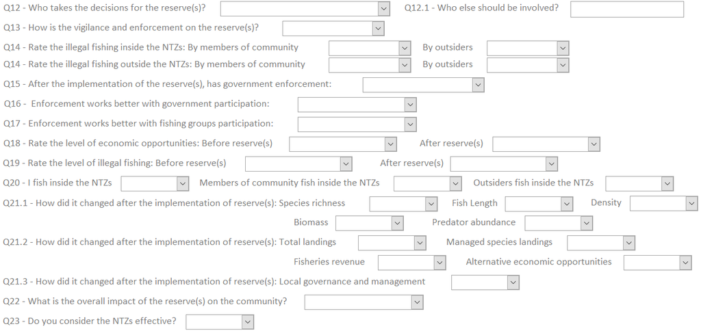

## Extensiones

- MAREA requiere que **todos** los datos estén en formato *.csv:
  - Valores coma-separados
  - Elimina fórmulas, validaciones y funciones en celdas
  - Elimina espacios en blanco antes y después de palabras ("Mero rojo" vs. "Mero rojo ")
  - Elimina filas en blanco al final del archivo
  - Archivos más ligeros

## Convertir *.xls a *csv

[figure not shown]

## Referencias

Lowndes, Julia S. Stewart, Benjamin D. Best, Courtney Scarborough, Jamie C. Afflerbach, Melanie R. Frazier, Casey C. O’Hara, Ning Jiang, and Benjamin S. Halpern. 2017. “Our Path to Better Science in Less Time Using Open Data Science Tools.” *Nat. Ecol. Evol.* 1 (6): 0160. doi:10.1038/s41559-017-0160.

## Bloque 4